# R 실습 2일차

## 데이터 프레임

- Excel 스프레드시트와 같은 형태
- 데이터 프레임은 데이터 유형에 상관없이 2차원 형태의 데이터 구조
- 행렬과 유사한 구조를 갖고 있지만 각기 다른 유형의 자료형을 사용할 수 있다는 점에서 행렬과 차이
- R에서 가장 많이 사용되고 있는 데이터 유형이므로 매우 중요

> **참고: 행렬은 동일한 유형의 자료형으로 이루어짐**

> **유용함수: `ls()` $\rightarrow$ 작업공간(메모리)에 존재하는 객체 리스트 출력**
- 다음은 일반적인 데이터프레임 형태

| 성명 | 국어 | 수학 |
| --- | --- | --- |
| 홍길동 | 80 | 94 |
| 박길동 | 97 | 100 |
| 김길동 | 85 | 76 |

```r
# 데이터프레임 생성
rm(list = ls())  # 메모리상 모든 객체 삭제하는 명령어!!
ID <- c(1:10)
SEX <- rep(c(0, 1), each = 5)
SEX <- factor(SEX, levels = c(0, 1), labels = c("Female", "Male"))
AGE <- c(34, 22, 54, 43, 44, 39, 38, 28, 31, 42)
AGE2 <- c(32, 22, 52, 41, 44, 39, 35, 28, 31, 40)
AGE3 <- c(32, 22, 52, 41, 44, 39, 35, 28, 31)
DBP <- c(112, 118, 132, 128, 128, 124, 121, 119, 124, 109)
HEIGHT <- c(165, 158, 161, 160, 168, 172, 175, 182, 168, 162)
WEIGHT <- c(52, 48, 59, 60, 48, 72, 73, 82, 64, 60)
DF <- data.frame(ID = ID, Sex = SEX, Age = AGE, DBP = DBP, HEIGHT = HEIGHT,
    WEIGHT = WEIGHT)
# DF 확인
str(DF)
```

```
'data.frame':   10 obs. of  6 variables:
 $ ID    : int  1 2 3 4 5 6 7 8 9 10
 $ Sex   : Factor w/ 2 levels "Female","Male": 1 1 1 1 1 2 2 2 2 2
 $ Age   : num  34 22 54 43 44 39 38 28 31 42
 $ DBP   : num  112 118 132 128 128 124 121 119 124 109
 $ HEIGHT: num  165 158 161 160 168 172 175 182 168 162
 $ WEIGHT: num  52 48 59 60 48 72 73 82 64 60
```

```r
names(DF)
```

```
[1] "ID"     "Sex"    "Age"    "DBP"    "HEIGHT" "WEIGHT"
```

```r
ncol(DF)
```

```
[1] 6
```

```r
nrow(DF)
```

```
[1] 10
```

```r
dim(DF)
```

```
[1] 10  6
```

```r
# 데이터 프레임 자료 확인
DF$Age
```

```
 [1] 34 22 54 43 44 39 38 28 31 42
```

```r
# 데이터프레임 변수 값 변환: DF$AGE를 AGE2로 변경
DF$Age <- AGE2
DF$Age
```

```
 [1] 32 22 52 41 44 39 35 28 31 40
```

```r
# 만약 입력하고자 하는 벡터의 길이가 DF의 행길이와 다르다면?
DF$Age <- AGE3
```

```
Error in `$<-.data.frame`(`*tmp*`, Age, value = c(32, 22, 52, 41, 44, : replacement has 9 rows, data has 10
```

```r
# 데이터 프레임에 BMI라는 변수를 추가하고 싶다면?
DF$Age <- AGE
DF$BMI <- WEIGHT/((HEIGHT/100)^2)
dim(DF)
```

```
[1] 10  7
```

```r
DF
```

```
   ID    Sex Age DBP HEIGHT WEIGHT      BMI
1   1 Female  34 112    165     52 19.10009
2   2 Female  22 118    158     48 19.22769
3   3 Female  54 132    161     59 22.76147
4   4 Female  43 128    160     60 23.43750
5   5 Female  44 128    168     48 17.00680
6   6   Male  39 124    172     72 24.33748
7   7   Male  38 121    175     73 23.83673
8   8   Male  28 119    182     82 24.75546
9   9   Male  31 124    168     64 22.67574
10 10   Male  42 109    162     60 22.86237
```

```r
# 데이터프레임 색인 6 번째 대상자의 성별확인
DF[6, 2]
```

```
[1] Male
Levels: Female Male
```

```r
DF[6, "Sex"]
```

```
[1] Male
Levels: Female Male
```

```r
## ID, 성별, BMI만 추출
DF[, c(1, 2, 7)]
```

```
   ID    Sex      BMI
1   1 Female 19.10009
2   2 Female 19.22769
3   3 Female 22.76147
4   4 Female 23.43750
5   5 Female 17.00680
6   6   Male 24.33748
7   7   Male 23.83673
8   8   Male 24.75546
9   9   Male 22.67574
10 10   Male 22.86237
```

```r
DF[, c("ID", "Sex", "BMI")]
```

```
   ID    Sex      BMI
1   1 Female 19.10009
2   2 Female 19.22769
3   3 Female 22.76147
4   4 Female 23.43750
5   5 Female 17.00680
6   6   Male 24.33748
7   7   Male 23.83673
8   8   Male 24.75546
9   9   Male 22.67574
10 10   Male 22.86237
```

```r
DF[, names(DF) %in% c("ID", "Sex", "BMI")]
```

```
   ID    Sex      BMI
1   1 Female 19.10009
2   2 Female 19.22769
3   3 Female 22.76147
4   4 Female 23.43750
5   5 Female 17.00680
6   6   Male 24.33748
7   7   Male 23.83673
8   8   Male 24.75546
9   9   Male 22.67574
10 10   Male 22.86237
```

```r
## 남자만 추출
DF[Sex == "Male", ]
```

```
Error in `[.data.frame`(DF, Sex == "Male", ): 객체 'Sex'를 찾을 수 없습니다
```

```r
DF[DF$Sex == "Male", ]
```

```
   ID  Sex Age DBP HEIGHT WEIGHT      BMI
6   6 Male  39 124    172     72 24.33748
7   7 Male  38 121    175     73 23.83673
8   8 Male  28 119    182     82 24.75546
9   9 Male  31 124    168     64 22.67574
10 10 Male  42 109    162     60 22.86237
```

```r
with(DF, DF[Sex == "Male", ])
```

```
   ID  Sex Age DBP HEIGHT WEIGHT      BMI
6   6 Male  39 124    172     72 24.33748
7   7 Male  38 121    175     73 23.83673
8   8 Male  28 119    182     82 24.75546
9   9 Male  31 124    168     64 22.67574
10 10 Male  42 109    162     60 22.86237
```

```r
## 첫 번째 대상자와 아이디 정보 제외
DF[-1, -1]
```

```
      Sex Age DBP HEIGHT WEIGHT      BMI
2  Female  22 118    158     48 19.22769
3  Female  54 132    161     59 22.76147
4  Female  43 128    160     60 23.43750
5  Female  44 128    168     48 17.00680
6    Male  39 124    172     72 24.33748
7    Male  38 121    175     73 23.83673
8    Male  28 119    182     82 24.75546
9    Male  31 124    168     64 22.67574
10   Male  42 109    162     60 22.86237
```

```r
head(DF)
```

```
  ID    Sex Age DBP HEIGHT WEIGHT      BMI
1  1 Female  34 112    165     52 19.10009
2  2 Female  22 118    158     48 19.22769
3  3 Female  54 132    161     59 22.76147
4  4 Female  43 128    160     60 23.43750
5  5 Female  44 128    168     48 17.00680
6  6   Male  39 124    172     72 24.33748
```

```r
tail(DF)
```

```
   ID    Sex Age DBP HEIGHT WEIGHT      BMI
5   5 Female  44 128    168     48 17.00680
6   6   Male  39 124    172     72 24.33748
7   7   Male  38 121    175     73 23.83673
8   8   Male  28 119    182     82 24.75546
9   9   Male  31 124    168     64 22.67574
10 10   Male  42 109    162     60 22.86237
```

```r
# 데이터프레임을 스프레드시트 형태로 보기 View(DF)
# 데이터프레임 요약 통계량
summary(DF)
```

```
       ID            Sex         Age             DBP
 Min.   : 1.00   Female:5   Min.   :22.00   Min.   :109.0
 1st Qu.: 3.25   Male  :5   1st Qu.:31.75   1st Qu.:118.2
 Median : 5.50              Median :38.50   Median :122.5
 Mean   : 5.50              Mean   :37.50   Mean   :121.5
 3rd Qu.: 7.75              3rd Qu.:42.75   3rd Qu.:127.0
 Max.   :10.00              Max.   :54.00   Max.   :132.0
     HEIGHT          WEIGHT           BMI
 Min.   :158.0   Min.   :48.00   Min.   :17.01
 1st Qu.:161.2   1st Qu.:53.75   1st Qu.:20.09
 Median :166.5   Median :60.00   Median :22.81
 Mean   :167.1   Mean   :61.80   Mean   :22.00
 3rd Qu.:171.0   3rd Qu.:70.00   3rd Qu.:23.74
 Max.   :182.0   Max.   :82.00   Max.   :24.76
```

## 자료 전처리

**목적**

1. **파일 입출력 마스터**
2. **`dplyr` 패키지를 이용해 DBP 자료 전처리 실습**

### 데이터 입출력

#### Excel 파일 불러오기

> **불러올 데이터: `output/DBP.xlsx`**

> **사용 패키지: `readxl`, `readr`**
- 사용함수
  - **`read_xlsx()`**
  - **`write_excel_csv()`**
  - **`save()`**
1. RStudio 메뉴로부터 불러오기
   - [메뉴] -> [Import Dataset] -> [Browser]에 파일경로 및 파일명 지정
2. `readxl` 패키지를 이용해서 불러오기
   - `read_xlsx()` 함수를 이용 -`read_xlsx(path, sheet, col_names)`: `path`(파일경로가 포함된 엑셀 파일명)에 해당하는 엑셀 파일에서 `sheet`의 변수명이 존재하는 데이터를 불러오기

```r
# install.packages()
library(tidyverse)
library(readxl)
DBP <- read_xlsx(path = "output/DBP.xlsx", sheet = 1, col_names = T)
head(DBP)
```

```
# A tibble: 6 x 9
  Subject   TRT  DBP1  DBP2  DBP3  DBP4  DBP5   Age   Sex
    <dbl> <chr> <dbl> <dbl> <dbl> <dbl> <dbl> <dbl> <chr>
1       1     A   114   115   113   109   105    43     F
2       2     A   116   113   112   103   101    51     M
3       3     A   119   115   113   104    98    48     F
4       4     A   115   113   112   109   101    42     F
5       5     A   116   112   107   104   105    49     M
6       6     A   117   112   113   104   102    47     M
```

```r
DBP2 <- with(DBP, DBP[TRT == "A", ])
write_excel_csv(DBP2, path = "output/DBP2.csv")
```

4. 작업공간 저장하기
   - `save()` 함수를 이용해 현재 작업공간(메모리) 상 존재하는 객체 저장
   - R 작업공간 저장파일의 확장자는 “.Rdata”
   - `output/실습1.Rdata`로 현재 존재하는 모든 객체를 저장
   - `output/실습2.Rdata`로 `DBP`, `DBP2`, `DF` 자료 저장

```r
# 모든 객체 저장
save(list = ls(), file = "output/실습1.Rdata")
## 선택 객체 저장
save(DBP, DBP2, DF, file = "output/실습2.Rdata")
```

### `dplyr` + `tidyr` 패키지를 이용한 데이터 전처리 예

- Hadley Wickham이 작성한 자료 전처리 특화 R Package
- 명령어가 직관적이고 사용하기 쉬움
- Chain (`%>%`, RStudio에서는 [Ctrl] + [Shift] + [M] 단축기 제공)이라는 연산자를 통해 각각의 데이터 조작을 연결해서 사용 가능
  - 최종 결과를 얻기 위한 불필요한 데이터프레임 생성 비율이 낮아짐
- 패키지 설치는 최근 `tidyverse`를 설치하면 자동적으로 두 개 패키지를 설치

> **참고: dplyr 패키지 간략한 사용법은 https://github.com/rstudio/cheatsheets/raw/master/source/pdfs/data-transformation-cheatsheet.pdf 와 http://had.co.nz/ggplot2/ 참조**
- `dplyr` + `tidyr` 전처리를 위한 기본함수

| 함수명 | 패키지 | 내용 |
| --- | --- | --- |
| filter() | dplyr | 지정 식에 맞는 데이터 추출 |
| select() | dplyr | 열의 추출 |
| mutate() | dplyr | 열 추가 및 변환 |
| arrange() | dplyr | 정렬 |
| group_by | dplyr | 지정한 열의 수준으로 그룹화 |
| summarise() | dplyr | 자료 요약 |
| gather() | tidyr | Long-format 데이터셋 생성 |
| spread() | tidyr | Wide-format 데이터셋 생성 |
| separate() | tidyr | 문자열 분리 후 변수 생성 |

> **`dplyr`의 일반적 사용 형태: `data %>% operation() %>% operation()`**
1. 예제 1: `iris` 데이터셋
   - 통계학자인 피셔Fisher가 소개한 데이터
   - 붓꽃의 3가지 종(setosa, versicolor, virginica)에 대해 꽃받침(sepal)과 꽃잎(petal)의 길이와 너비를 정리한 데이터

| 변수명 | 설명 | 타입 |
| --- | --- | --- |
| Sepal.Length | 꽃받침 길이 | numeric |
| Sepal.Width | 꽃받침 너비 | numeric |
| Petal.Length | 꽃잎 길이 | numeric |
| Petal.Width | 꽃잎 너비 | numeric |
| Species | 붓꽃의 종(setosa, versicolor, virginica) | factor |

> **문제 1**
1. iris 데이터에서 setosa 종만 뽑아
2. Sepal.Length와 Sepal.Width 변수를 추출 후
3. 두 변수를 더한 새로운 변수 `Sepal_sum`을 만들고 동시에 `Sepal_sum`을 제곱한 변수 `Sepal_square` 컬럼 추가 후
4. `Sepal_sum` 기준으로 내림차순 하기

```r
data(iris)
library(tidyverse)
Q1 <- iris %>% filter(Species == "setosa") %>% select(Sepal.Length,
    Sepal.Width) %>% mutate(Sepal_sum = Sepal.Length + Sepal.Width,
    Sepal_square = Sepal_sum^2) %>% arrange(desc(Sepal_sum))  # `desc()` dplyr 패키지에서 제공하는 내림차순 반환 함수
head(Q1)
```

```
  Sepal.Length Sepal.Width Sepal_sum Sepal_square
1          5.7         4.4      10.1       102.01
2          5.8         4.0       9.8        96.04
3          5.5         4.2       9.7        94.09
4          5.7         3.8       9.5        90.25
5          5.4         3.9       9.3        86.49
6          5.4         3.9       9.3        86.49
```

```r
mDBP <- DBP %>% mutate(Sex = factor(Sex), TRT = factor(TRT)) %>%
    gather(tmp, value, DBP1:DBP5) %>% separate(tmp, c("DBP",
    "VISIT"), sep = "P") %>% select(-DBP) %>% mutate(VISIT = as.numeric(VISIT))
```

> **문제 3**
1. **문제 2**와 동일하게 1-3 과정을 진행한 후(단 `tmp`를 `Visit`으로 바꿔서),
2. 각 `TRT`에 따른 `VISIT` 별 평균을 계산한 뒤,
3. 다시 `VISIT`의 각 `DBP1`부터 `DBP5`의 수준을 wide-format으로 변경

```r
mDBP2 <- DBP %>%
  mutate(Sex = factor(Sex),
         TRT = factor(TRT)) %>%
  gather(VISIT, value, DBP1:DBP5) %>%
  group_by(TRT, VISIT) %>%
  summarise(Mean = mean(value)) %>%
  ungroup(.) %>% #group화 된 변수는 펼치거나 모을 수 없어서 그룹지정 해지 함수 사용
  spread(VISIT, Mean)
```

## `ggplot2` 패키지를 이용한 그래픽 생성

- Hadley Wickham이 만든 Lee Wilkinson의 “Grammar of graphics” 기반 R 그래픽 패키지
- Grammar of graphics의 개념
  - 자료(data)를 각 기하학적인 객체(**geom**etric object 예: 점, 선, 면 등)에 미적(**aes**thetic) 속성을 2차원 좌표공간(**coord**inate)상에 매핑 시켜 그래픽을 생성하는 체계
- `ggplot`의 기본 사용
  - `data(mtcars)`

    ```r
    [, 1]    mpg     Miles/(US) gallon
    [, 2]    cyl     Number of cylinders
    [, 3]    disp    Displacement (cu.in.)
    [, 4]    hp  Gross horsepower
    [, 5]    drat    Rear axle ratio
    [, 6]    wt  Weight (1000 lbs)
    [, 7]    qsec    1/4 mile time
    [, 8]    vs  V/S
    [, 9]    am  Transmission (0 = automatic, 1 = manual)
    [,10]    gear    Number of forward gears
    [,11]    carb    Number of carburetors
    ```

> **`data` + `geom` $\rightarrow$ graph**
- 기본적으로 `ggplot()` 함수를 사용

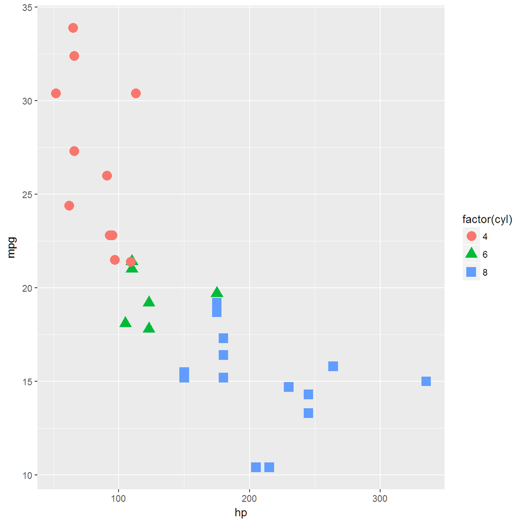

```r
data(mtcars)
ggplot(data = mtcars) + aes(x = hp, y = mpg, color = factor(cyl),
    shape = factor(cyl)) + geom_point(size = 4)
```

- 기본함수
  - `ggplot()`
  - `aes()`
  - `geom` 계열 함수
    - `geom_point()`: 산점도
    - `geom_line()`: 선도표
    - `geom_boxplot()`: 상자그림
    - `geom_bar()`: 막대그림
    - `geom_errorbar()`: 오차막대
    - 그외 다수
  - `scale` 계열함수
  - `facet` 계열함수
  - `theme` 계열 함수

> 예제: DBP 자료

DBP 자료를 처리군 별로 성별에 따른 visit별 혈압 별 평균에 대한 프로파일 도표(표준편차 포함) 만들기

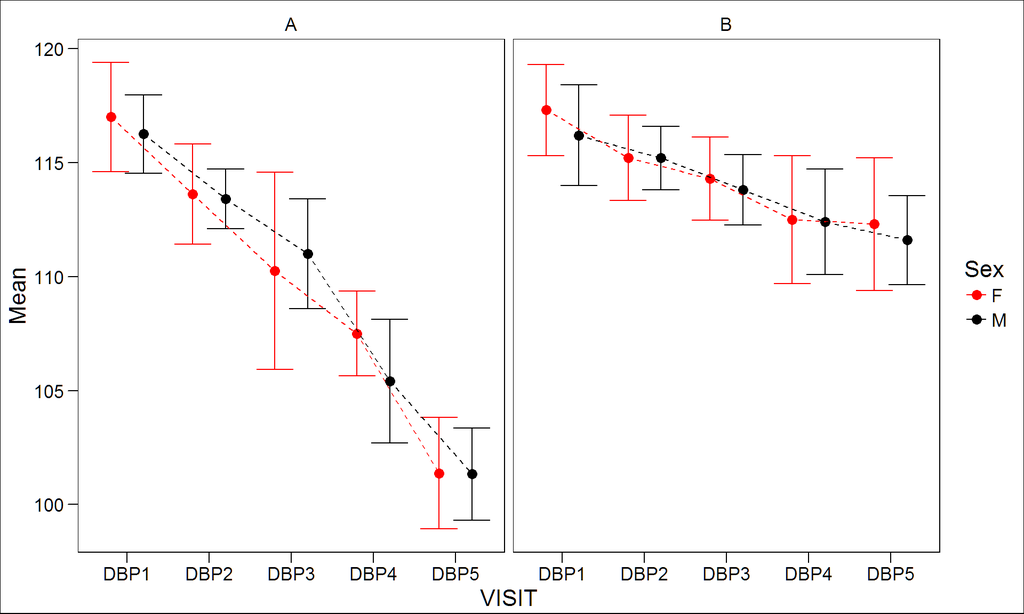